# Reproducible Research: Peer Assessment 1

## Loading and preprocessing the data

```r
setwd("C:\\Tejo\\Datascience\\ReproducibleResearch\\Week2\\Assignment\\Assignment\\RepData_PeerAssessment1")
dir()  ## list the files under the current working directory.
```

```
##  [1] "activity.csv"              "activity.zip"
##  [3] "Avgstepsinterval.png"      "doc"
##  [5] "histtotalsteps1.png"       "HistTotalStepsimputed.png"
##  [7] "instructions_fig"          "PA1_template.html"
##  [9] "PA1_template.md"           "PA1_template.Rmd"
## [11] "panelWeekdayweekend.png"   "README.md"
```

```r
library(plyr)
library(lattice)
```

```r
library(ggplot2)
zipfilename<-"activity.zip"
unzip(zipfilename)  ## unzip the file.
activity<-read.csv(file="activity.csv", header = TRUE, sep = ",")
```

Lets check the dimension of the activity data

```r
dim(activity)
```

```
## [1] 17568     3
```

lets verify how many NA values present?

```r
summary(activity$steps)
```

```
##    Min. 1st Qu.  Median    Mean 3rd Qu.    Max.    NA's
##    0.00    0.00    0.00   37.38   12.00  806.00    2304
```

lets convert the date factor variable into a date variable.

```r
activity$date<-as.Date(as.character(activity$date, format = "%Y%m%d"))
activity$interval<-format(strptime(sprintf("%04d", activity$interval), format="%H%M"), format = "%H:%M")
```

## What is mean total number of steps taken per day?

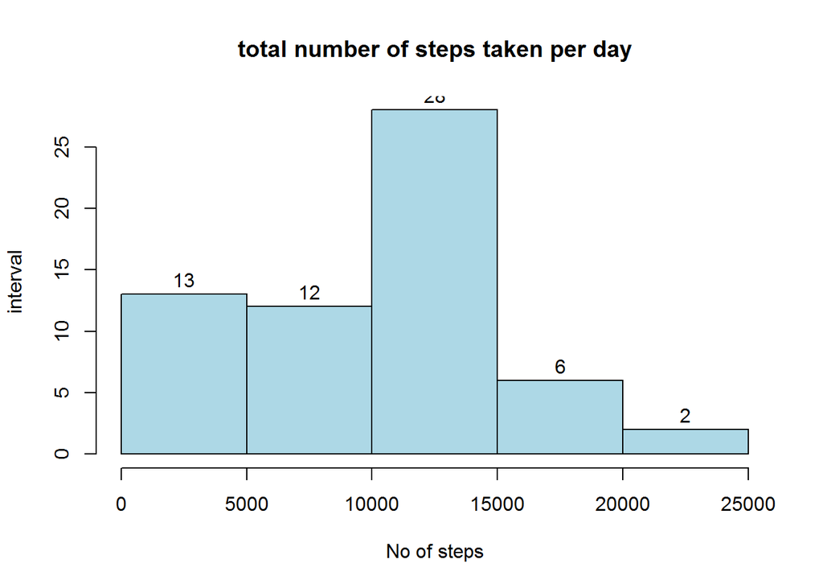

```r
actsteps<-ddply(activity, .(date), summarise, stepsperday= sum(steps, na.rm = TRUE))
hist(actsteps$stepsperday, xlab="No of steps", ylab= "interval", main= "total number of steps taken per day"
     , col = "lightblue", labels=TRUE)
```

mean and median of the total number of steps taken per day

```r
totalMeanStepsperday <- mean(actsteps$stepsperday)
totalMedianStepsperday <- median(actsteps$stepsperday)

print (paste("Mean:", totalMeanStepsperday))
```

```
## [1] "Mean: 9354.22950819672"
```

```r
print (paste("Median:", totalMedianStepsperday))
```

```
## [1] "Median: 10395"
```

## What is the average daily activity pattern?

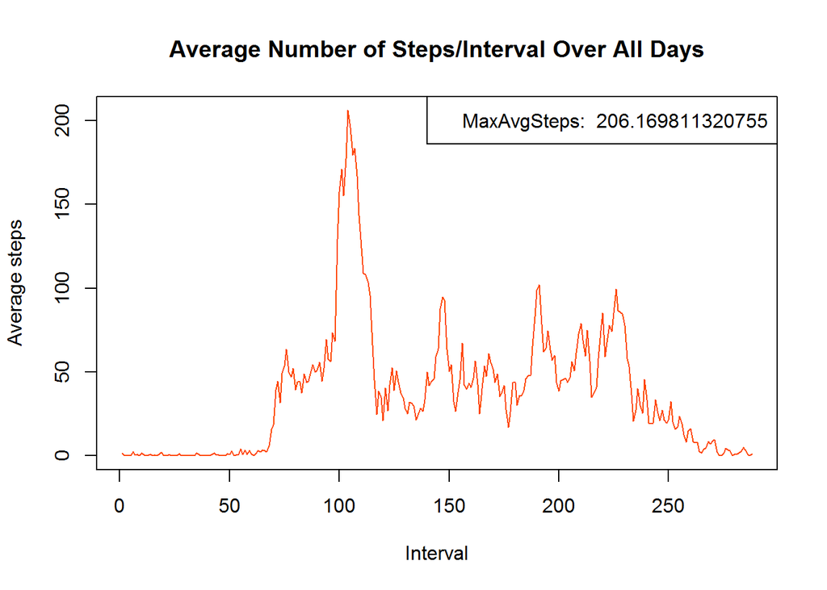

```r
avgactivity<-ddply(activity,.(interval) ,summarise,AvgSteps = mean(steps, na.rm = TRUE))

plot(avgactivity$AvgSteps, type="l", main = "Average Number of Steps/Interval Over All Days", xlab = "Interval", ylab = "Average steps", col="orangered")
MaxAvg<-avgactivity[which.max(avgactivity$AvgSteps),]$AvgSteps
legend("topright", paste("MaxAvgSteps: ", MaxAvg))
```

## Imputing missing values

1. Calculate and report the total number of missing values in the dataset (i.e. the total number of rows with NAs)

```r
table(is.na(activity$steps))[2]
```

```
## TRUE
## 2304
```

2. Devise a strategy for filling in all of the missing values in the dataset. The strategy does not need to be sophisticated. For example, you could use the mean/median for that day, or the mean for that 5-minute interval, etc.
1. Create a new dataset that is equal to the original dataset but with the missing data filled in.

```r
mergedactivity<-merge(activity, avgactivity, by.x = "interval", by.y = "interval")

index<-is.na(mergedactivity$steps)
mergedactivity$steps[index]<- mergedactivity$AvgSteps[index]
```

b.Make a histogram of the total number of steps taken each day.

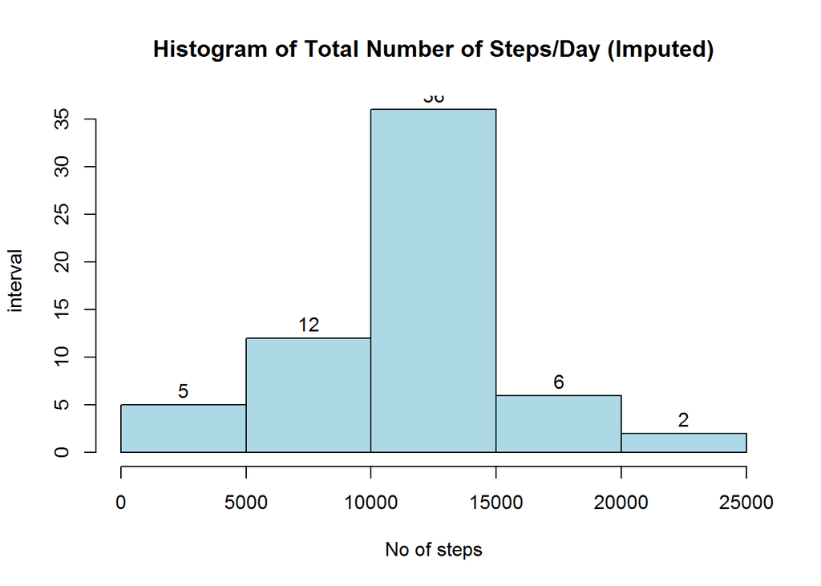

```r
actsteps<-ddply(mergedactivity, .(date), summarise, stepsperday= sum(steps))
hist(actsteps$stepsperday, xlab="No of steps", ylab= "interval", main= "Histogram of Total Number of Steps/Day (Imputed)"
     , col = "lightblue", labels=TRUE)
```

3. and Calculate and report the mean and median total number of steps taken per day.

```r
mean(actsteps$stepsperday)
```

```
## [1] 10766.19
```

```r
median(actsteps$stepsperday)
```

```
## [1] 10766.19
```

## Are there differences in activity patterns between weekdays and weekends?

1. Create a new factor variable in the dataset with two levels - “weekday” and “weekend” indicating whether a given date is a weekday or weekend day.

```r
mergedactivity$Weekday<-mergedactivity$date
wdays<- c("Monday", "Tuesday", "Wednesday", "Thursday", "Friday", "Saturday", "Sunday")
wdays[c(6,7)]
```

```
## [1] "Saturday" "Sunday"
```

```r
mergedactivity$Weekday<-factor(weekdays(mergedactivity$date, abbreviate=FALSE) %in% wdays[c(6,7)], levels = c(TRUE, FALSE), labels = c("Weekends", "Weekday"))
```

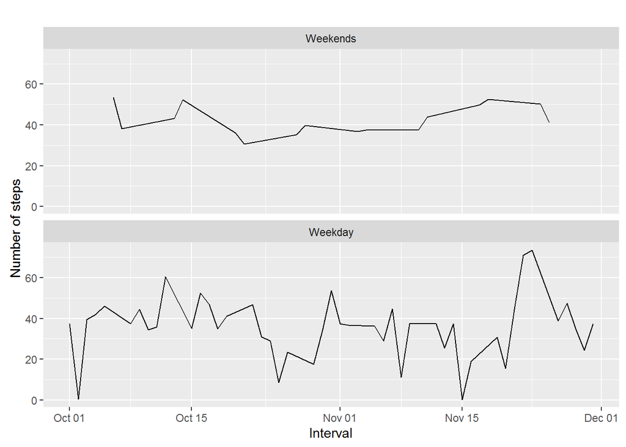

```r
weekdayactivity<-ddply(mergedactivity, .(date,Weekday), summarise, AvgSteps= mean(steps))

##xyplot(AvgSteps~date|Weekday, data = weekdayactivity,
##               ylab="Average Steps",
##               type = "l",
##               main=" ")

qplot(date, AvgSteps, data=weekdayactivity, geom=c("line"),
    xlab="Interval", ylab="Number of steps", main="") +
    facet_wrap(~ Weekday, ncol=1)
```

```r
##dev.copy(png, 'HistTotalStepsimputed.png')
##dev.off()
```